# ITS_analysis

Ignacio Romero

2023-11-07

The dataset contains 1631 sequences that belong to the Fungi Kingdom and 10 sequences that are not Fungi but Rhizaria (Phylum Cercozoa)

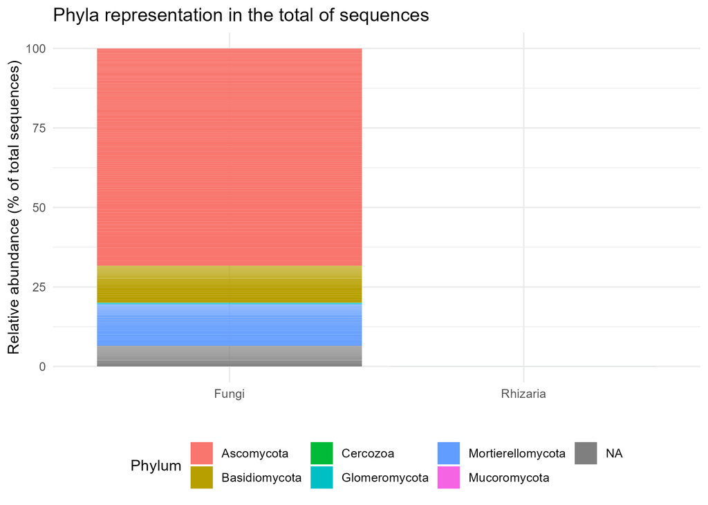

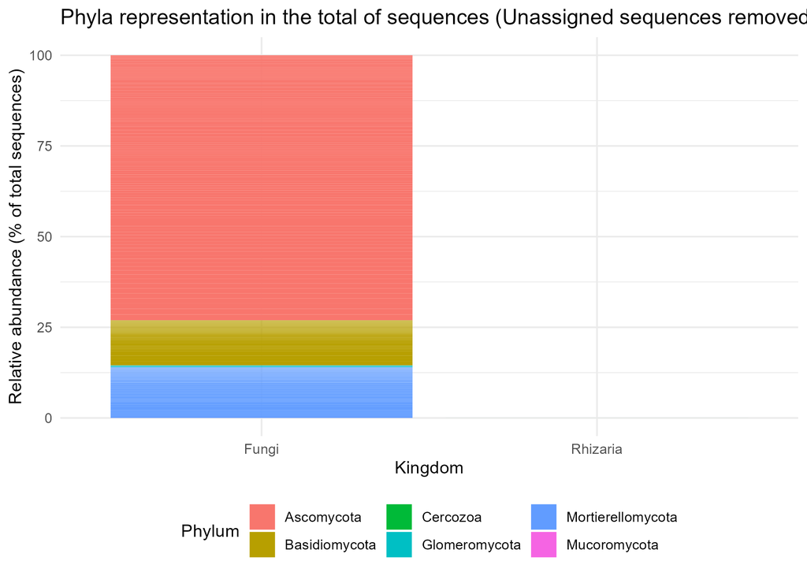

### Rarefaction plots

#### Rarefaction plot by treatment

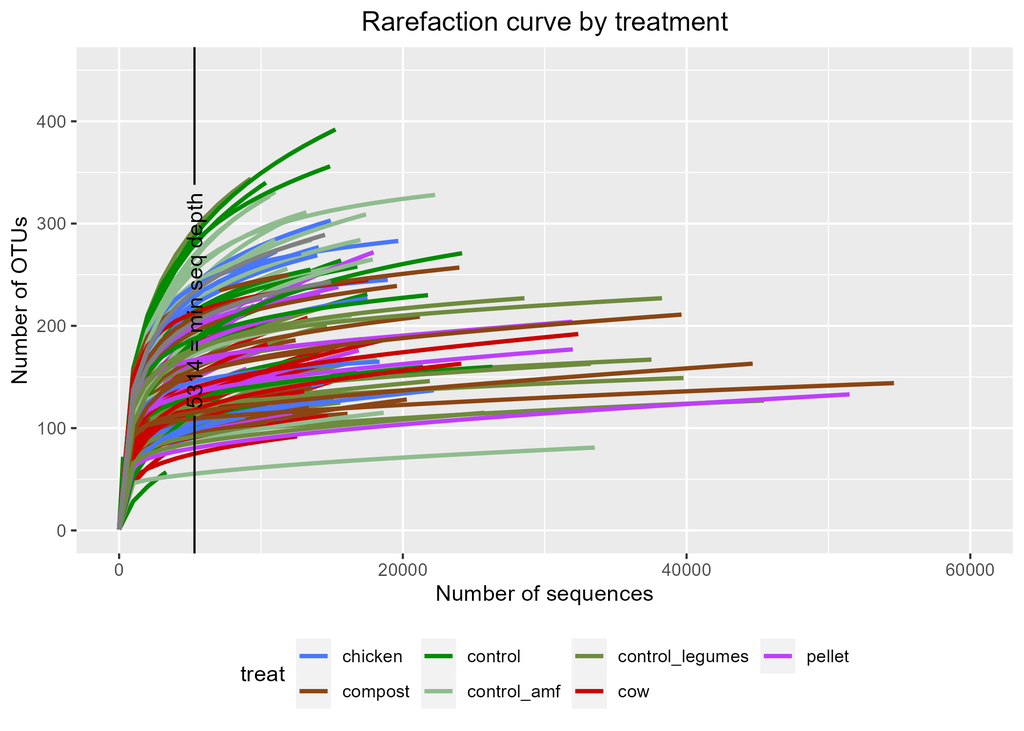

Rarefaction curve showing the treatments

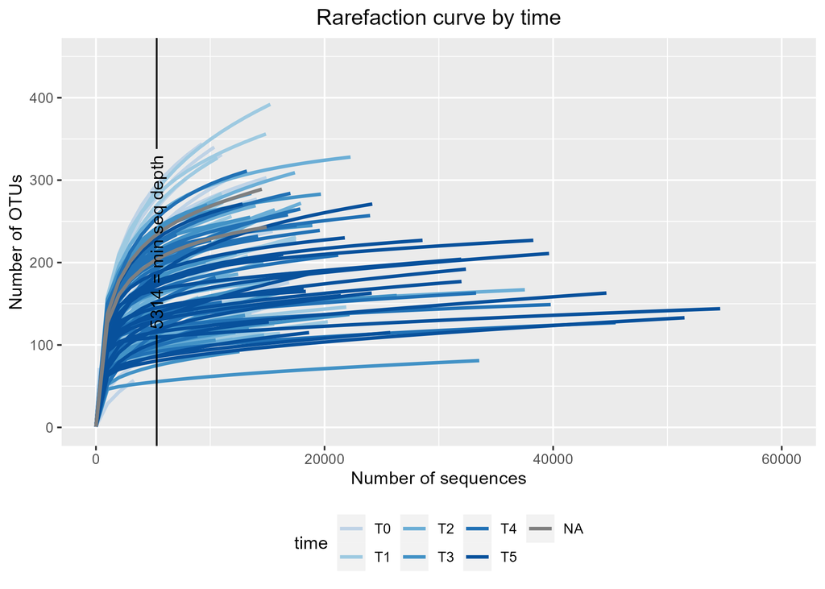

## Rarefy the data

A way to fight the differences in the sequencing depth is rarefying the data. This statistical process randomly samples the same number of sequences, obtaining a higher fidelity of representation of the taxa composition of each sample. It is performed in loop for a high number of times (500, for example) so that the random choice of taxa is warrantied.

The following code chunk performs rarefaction 500 times, then it calculates the Shannon index (as the negative sum of all the frequencies times the logarithm of the frequencies), the richness and the evenness with the average abundances resulting of those 500 iterations. To avoid wasting time, the results are saved to an object and loaded in a separate chunk.

```r
zotu97
```

```
## phyloseq-class experiment-level object
## otu_table()   OTU Table:         [ 1641 taxa and 126 samples ]
## sample_data() Sample Data:       [ 126 samples by 4 sample variables ]
## tax_table()   Taxonomy Table:    [ 1641 taxa by 7 taxonomic ranks ]
```

```r
zotu97.rar
```

```
## phyloseq-class experiment-level object
## otu_table()   OTU Table:         [ 1641 taxa and 126 samples ]
## sample_data() Sample Data:       [ 126 samples by 7 sample variables ]
## tax_table()   Taxonomy Table:    [ 1641 taxa by 7 taxonomic ranks ]
```

## Alpha diversity

### Shanon

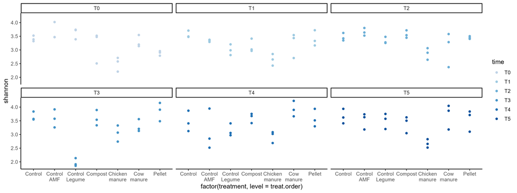

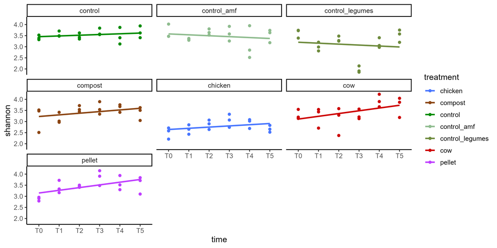

### Evenness

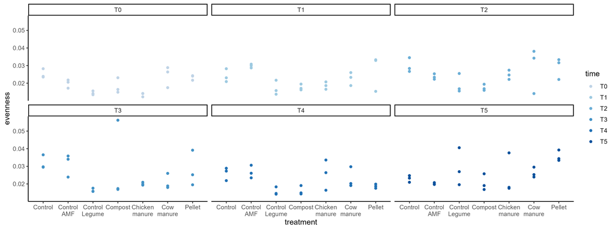

[figure not shown]

### Richness

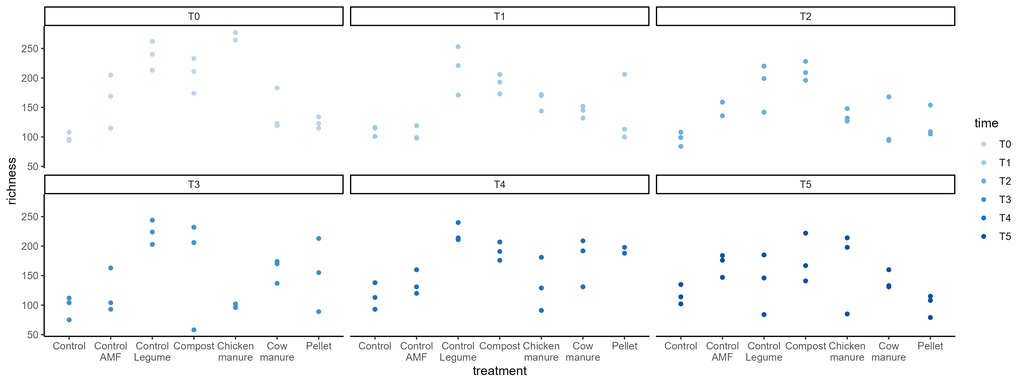

[figure not shown]